# Ejercicios para desarrollar en R

JRojas, MRamirez, LRomero,ADarghan

6/24/2020

# Introducción

Previo a la solución de los ejercicios es necesario instalar y cargar las siguientes librerías.

```r
library(scatterplot3d)
library(matrixcalc)
require(MASS)
```

# Punto 1.

Dada la información siguiente, resuelva:

$X=[5,1,3] , Y=[-1,3,1]$

1. Graficar los dos vectores

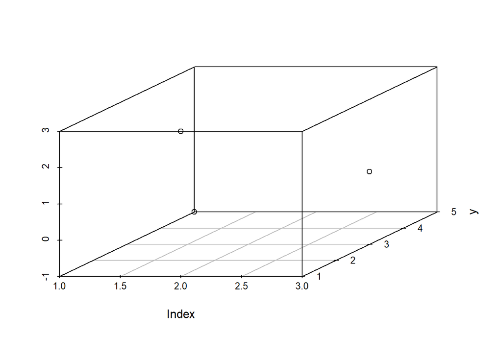

```r
#Vectores de entrada
x=c(5,1,3)
y=c(-1,3,1)

#Función para graficar los vectores
scatterplot3d(x,y)
```

2. Encontrar a partir de los vectores datos: i) largo de x; ii) ángulo (x, y)

```r
#Cálculo del largo de x: Recordar el teorema de Pitagoras
lgx=sqrt(5^2+1^2+3^2)
lgy=sqrt((-1)^2+3^2+1^2)

#Cálculo del ángulo entre dos vectors a partir del producto punto

# 1) Cálculo de la transpuesta de los vectores

xt=t(c(5,1,3))
yt=t(c(-1,3,1))

# 2) Cálculo del producto punto

pp=xt%*%y;

# 3) Cálculo del ángulo
cosfi=pp/(lgx*lgy)
fi=acos(cosfi);fi
```

```
##         [,1]
## [1,] 1.51981
```

3. Desde $\bar{x}=3$ y $\bar{y}=1$, gráfique $[5 - 3,1-3,3-3]=[2,(-2),0]$ y $[(-1) - 1,3-1,1-1]=[(-2),2,0]$

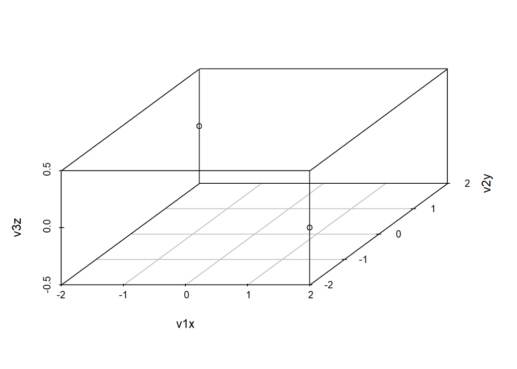

```r
xbarra <- t(c(3,3,3))
ybarra <- t(c(1,1,1))

v1 <- x-xbarra
v2 <- y-ybarra

v1x <- c(2,-2)
v2y <- c(-2,2)
v3z <- c(0,0)

scatterplot3d(v1x, v2y, v3z)
```

# Punto 2.

Dada las siguiente matrices

```r
A = matrix(c(-1,3,4,2), ncol=2, byrow=TRUE)
B = matrix(c(-4,-3,1,-2,-2,0), ncol=2, byrow=TRUE)
C = matrix(c(5,-4,2),ncol=1,byrow = TRUE)
```

### Realizar las siguientes multiplicaciones

### a) $5A$

```r
5*A
```

```
##      [,1] [,2]
## [1,]   -5   15
## [2,]   20   10
```

### b) $BA$

```r
B%*%A
```

```
##      [,1] [,2]
## [1,]   -8  -18
## [2,]   -9   -1
## [3,]    2   -6
```

### c) $A^TB^T$

```r
t(A)%*%t(B)
```

```
##      [,1] [,2] [,3]
## [1,]   -8   -9    2
## [2,]  -18   -1   -6
```

### d) $C^TB$

```r
t(C)%*%B
```

```
##      [,1] [,2]
## [1,]  -28   -7
```

### e) $AB$ está definida?

```r
try(A%*%B)
```

```
## Error in A %*% B : non-conformable arguments
```

```r
#No está definida por la dimensión de las matrices
```

# Punto 3.

Verifique las siguientes propiedades de la matriz transpuesta cuando:

$$A=\begin{bmatrix}2 & 1\\ 1 & 3\end{bmatrix}, B=\begin{bmatrix}1 & 4 & 2\\ 5 & 0 & 3\end{bmatrix}, C=\begin{bmatrix}1 & 4\\ 3 & 2\end{bmatrix}$$

```r
A = matrix(c(2,1,1,3), ncol=2, byrow=TRUE)
B = matrix(c(1,4,2,5,0,3), ncol=3, byrow=TRUE)
C = matrix(c(1,4,3,2), ncol=2, byrow=TRUE)
```

1. $(A^T)^T=A$

```r
t(t(A)) #Es la misma A
```

```
##      [,1] [,2]
## [1,]    2    1
## [2,]    1    3
```

2. $(C^T)^-1=(C^-1)^T$

```r
D=matrix.inverse(t(C));D
```

```
##      [,1] [,2]
## [1,] -0.2  0.3
## [2,]  0.4 -0.1
```

```r
E=t(matrix.inverse(C));E
```

```
##      [,1] [,2]
## [1,] -0.2  0.3
## [2,]  0.4 -0.1
```

```r
# Son de igual resultado, sin envargo al aplicar el validador lógico de R aparece que son diferentes
D==E
```

```
##       [,1]  [,2]
## [1,] FALSE  TRUE
## [2,] FALSE FALSE
```

```r
D=t(A%*%B)
E=t(B)%*%t(A)
D==E # El restultado es que son iguales
```

```
##      [,1] [,2]
## [1,] TRUE TRUE
## [2,] TRUE TRUE
## [3,] TRUE TRUE
```

# Punto 4.

Cuando $A^-1$ and $B^-1$ existen, pruebe lo siguiente:

1. $(A^T)^-1=(A^-1)^T$

```r
matrix.inverse(t(A))==t(matrix.inverse(A)) #Correcto, la validación es verdadera
```

```
##      [,1] [,2]
## [1,] TRUE TRUE
## [2,] TRUE TRUE
```

2. $(AB)^-1=B^-1A^-1$

```r
try(matrix.inverse(A%*%B)==(matrix.inverse(B))%*%(matrix.inverse(A))) # La matrix B no es cuadrada
```

```
## Error in matrix.inverse(A %*% B) : argument x is not a square matrix
```

# Punto 5.

Verifique que:

$$Q=\begin{bmatrix}\frac{5}{13} & \frac{12}{13}\\ -\frac{12}{13} & \frac{5}{13}\end{bmatrix}$$

Es una matriz ortogonal

```r
Q=matrix(c(5/13,12/13,-(12/13),5/13),nrow = 2, byrow = TRUE)
#Para probar se multiplica por la transpuesta
Q%*%t(Q)
```

```
##      [,1] [,2]
## [1,]    1    0
## [2,]    0    1
```

```r
#Como el resultado es la idéntica se define que es ortogonal
```

# Punto 6.

Dada la matriz $A$:

Indicar si: * Simétrica * Definida Positiva

```r
A<-matrix(c(9,-2,-2,6), ncol=2, byrow=TRUE)

### SIMETRIA

A == t(A)
```

```
##      [,1] [,2]
## [1,] TRUE TRUE
## [2,] TRUE TRUE
```

Es simétrica debido a que la matriz es igual a su transpuesta.

Para indicar si es positiva se definen los vectores $g$, $m$ y $n$ los cuales corresponden a tres combinaciones del vector:

$$\begin{bmatrix}
8\\
5
\end{bmatrix}$$

Para realizar la multiplicación de su trasnpuesto con la matriz $A$ con el vector, como se observa a continuación:

```r
### MATRIZ POSITIVA

g<-c(-8,-5)
m<-c(8,-5)
n<-c(-8,5)

t(g)%*%A%*%g
```

```
##      [,1]
## [1,]  566
```

```r
t(m)%*%A%*%m
```

```
##      [,1]
## [1,]  886
```

```r
t(n)%*%A%*%n
```

```
##      [,1]
## [1,]  886
```

Se observa que con los tres vectores, el resultado es un valor positivo y se puede asumir que la matriz es positiva.

# Punto 7.

Dada la matriz del punto 6 definir:

- Determinar los valores y vectores propios
- Encontrar la inversa
- Encontrar los valores y vectores propios de la matriz inversa

```r
eigen(A)
```

```
## eigen() decomposition
## $values
## [1] 10  5
##
## $vectors
##            [,1]       [,2]
## [1,] -0.8944272 -0.4472136
## [2,]  0.4472136 -0.8944272
```

Con la función eigen se obtiene los valores y vectores propios de la matriz $A$

```r
solve(A)
```

```
##      [,1] [,2]
## [1,] 0.12 0.04
## [2,] 0.04 0.18
```

Con la función solve se obtiene la matriz inversa de $A$

```r
eigen(solve(A))
```

```
## eigen() decomposition
## $values
## [1] 0.2 0.1
##
## $vectors
##           [,1]       [,2]
## [1,] 0.4472136 -0.8944272
## [2,] 0.8944272  0.4472136
```

Con la función eigen y solve se obtiene los valores y vectores propios de la matriz inversa de $A$

# Punto 8.

Dada la matriz $A$:

$$\begin{bmatrix}
1 & 2\\
2 & -2
\end{bmatrix}$$

Encontrar: * Matriz Inversa * Valores y vectores propios de la matriz inversa

```r
A<-matrix(c(1,2,2,-2), ncol=2, byrow=TRUE)

solve(A)
```

```
##           [,1]       [,2]
## [1,] 0.3333333  0.3333333
## [2,] 0.3333333 -0.1666667
```

```r
eigen(solve(A))
```

```
## eigen() decomposition
## $values
## [1]  0.5000000 -0.3333333
##
## $vectors
##            [,1]       [,2]
## [1,] -0.8944272  0.4472136
## [2,] -0.4472136 -0.8944272
```

# Punto 10.

Dada la matriz $A$:

$$\begin{bmatrix}
4 & 4.001\\
4.001 & 4.002
\end{bmatrix}$$

Dada la matriz $B$:

$$\begin{bmatrix}
4 & 4.001\\
4.001 & 4.002001
\end{bmatrix}$$

Se observa que en la posición $(2,2)$ poseen una diferencia significativamente pequeña, sin embargo las columnas de las dos columnas son muy cercanas a ser dependientes. Demuestre que $A^{-1} = -3B^{-1}$ con el propósito de tener en cuenta que los resultados cambian en estas situaciones.

```r
A<-matrix(c(4,4.001,4.001,4.002), ncol=2, byrow=TRUE)
B<-matrix(c(4,4.001,4.001,4.002001), ncol=2, byrow=TRUE)

solve(A) == -3*solve(B)
```

```
##       [,1]  [,2]
## [1,] FALSE FALSE
## [2,] FALSE FALSE
```

```r
solve(A)
```

```
##          [,1]     [,2]
## [1,] -4002000  4001000
## [2,]  4001000 -4000000
```

```r
-3*solve(B)
```

```
##          [,1]     [,2]
## [1,] -4002001  4001000
## [2,]  4001000 -4000000
```

Apesar de que el operador lógico indica que los valores no son iguales, al observar las dos matrices por separado, se ve que se puede considerar que son idénticas.

# Punto 11.

```r
A<-matrix(c(5,0,0,0,0,1,0,0,0,0,3,0,0,0,4), ncol=4, byrow=TRUE)
### Funcion para multiplicar elementos de un vector

product <- function(vec){
  out <- 1
  for(i in 1:length(vec)){
    out <- out*vec[i]
  }
  out
}

det(A)
```

```
## [1] 75
```

```r
diag(A)
```

```
## [1] 5 1 3 5
```

```r
det(A) == product(diag(A))
```

```
## [1] FALSE
```

# Punto 12.

```r
A<-matrix(c(0,1,2,3,1,0,4,5,2,4,0,6,3,5,6,0), ncol=4, byrow=TRUE)

d<-eigen(A)

det(A) == product(d$values)
```

```
## [1] FALSE
```

# Punto 13.

Indicar si $3x_1^{2} + 3x_2^{2} - 2x_1x_2$ es una forma cuadrática.

Como primera medida se construye la matriz $A$:

```r
A<-matrix(c(3,-1,-1,3), ncol=2, byrow=TRUE)
```

Se valida que el determinante de la matriz $A$ sea igual a la multiplicación de sus valores propios:

```r
d<-eigen(A)
det(A) == product(d$values)
```

```
## [1] FALSE
```

```r
det(A)
```

```
## [1] 8
```

```r
product(d$values)
```

```
## [1] 8
```

Se toma el mismo ejemplo del punto 6 para validar si es una forma cuadrática:

```r
g<-c(-8,-5)
m<-c(8,-5)
n<-c(-8,5)

t(g)%*%A%*%g
```

```
##      [,1]
## [1,]  187
```

```r
t(m)%*%A%*%m
```

```
##      [,1]
## [1,]  347
```

```r
t(n)%*%A%*%n
```

```
##      [,1]
## [1,]  347
```

El resultado indica que si se puede considerar cuadrática.

# Punto 14.

Dada la matriz $A$:

$$\begin{bmatrix}
4 & 0 & 0\\
0 & 9 & 0\\
0 & 0 & 1
\end{bmatrix}$$

Encontrar: * $\sum^{-1}$ * Los valores propios de $\sum$ * Los valores propios de $\sum^{-1}$

```r
A=matrix(c(4,0,0,0,9,0,0,0,1), nrow = 3, byrow = TRUE)

matrix.inverse(A)
```

```
##      [,1]      [,2] [,3]
## [1,] 0.25 0.0000000    0
## [2,] 0.00 0.1111111    0
## [3,] 0.00 0.0000000    1
```

```r
eigen(A)
```

```
## eigen() decomposition
## $values
## [1] 9 4 1
##
## $vectors
##      [,1] [,2] [,3]
## [1,]    0    1    0
## [2,]    1    0    0
## [3,]    0    0    1
```

```r
eigen(matrix.inverse(A))
```

```
## eigen() decomposition
## $values
## [1] 1.0000000 0.2500000 0.1111111
##
## $vectors
##      [,1] [,2] [,3]
## [1,]    0    1    0
## [2,]    0    0    1
## [3,]    1    0    0
```

# Punto 15.

Dada la matriz $\sum$:

$$\begin{bmatrix}
25 & -2 & 4\\
-2 & 4 & 1\\
4 & 1 & 9
\end{bmatrix}$$

Encontrar: * Las matrices $\rho$ y $V^{1/2}$ * Demuestre que $V^{1/2} \rho V^{1/2} = \sum$

```r
## A

A<-matrix(c(25,-2,4,-2,4,1,4,1,9), ncol=3, byrow=TRUE)
desv<-diag(diag(A^0.5),3,3) ##Matriz Desviacion Estándar
desv
```

```
##      [,1] [,2] [,3]
## [1,]    5    0    0
## [2,]    0    2    0
## [3,]    0    0    3
```

```r
cor<-solve(desv)%*%A%*%solve(desv) ## Matriz de Correlacción
cor
```

```
##            [,1]       [,2]      [,3]
## [1,]  1.0000000 -0.2000000 0.2666667
## [2,] -0.2000000  1.0000000 0.1666667
## [3,]  0.2666667  0.1666667 1.0000000
```

```r
## B

desv%*%cor%*%desv
```

```
##      [,1] [,2] [,3]
## [1,]   25   -2    4
## [2,]   -2    4    1
## [3,]    4    1    9
```

# Punto 16

Dadas las matrices:

$$A=\begin{bmatrix}1 & -2 & 3\\2 & 3 & -1\\-3 & 1 & 2\end{bmatrix},B=\begin{bmatrix}1 & 0 & 2\\0 & 1 & 2\\1 & 2 & 0\end{bmatrix}$$

Muestre que: * $AB\neq BA$

```r
A <- matrix(c(1,2,-3,-2,3,1,3,-1,2), ncol= 3)
B <- matrix(c(1,0,1,0,1,2,2,2,0), ncol= 3)

AB <- A%*%B
BA <- B%*%A

AB == BA
```

```
##       [,1]  [,2]  [,3]
## [1,] FALSE FALSE FALSE
## [2,] FALSE FALSE FALSE
## [3,] FALSE FALSE FALSE
```

```r
# RESPUESTA: efectivamente los resultados cambian, la multiplicación de matrices no es conmutativa
```

# Punto 17

Demuestre que la matriz
$$A=\begin{bmatrix}
2 & -2 & -4\\
-1 & 3 & 4\\
1 & -2 & -3
\end{bmatrix}$$

es idempotente.

```r
# Una matriz es idempotente cuando es igual a su cuadrado, es decir A*A = A
A <- matrix(c(2,-1,1,-2,3,-2,-4,4,-3), ncol= 3)
AA <- A%*%A

A == AA
```

```
##      [,1] [,2] [,3]
## [1,] TRUE TRUE TRUE
## [2,] TRUE TRUE TRUE
## [3,] TRUE TRUE TRUE
```

```r
#RESPUESTA: Efectivamente la matriz A17 es idempotente
```

# Punto 18

Demuestre que
$$det\begin{bmatrix}
12 & 5 & -3 & 2\\
8 & 6 & 4 & 6\\
8 & 3 & -1 & -1\\
12 & 4 & 2 & 4
\end{bmatrix}=616$$

```r
A <- matrix(c(12,8,8,12,5,6,3,4,-3,4,-1,2,2,6,-1,4), ncol= 4)

Adet <- det(A)
Adet # 616
```

```
## [1] 616
```

```r
# Efectivamente la respuesta es 616
```

# Punto 19

Teniendo las matrices

$$A=\begin{bmatrix}1 & 2 & 1\\2 & 4 & 6\\3 & 1 & 2\end{bmatrix},B=\begin{bmatrix}-1 & 2 & -3\\
2 & -1 & 4\\3 & 4 & 1\end{bmatrix}$$

Pruebe que: * $|AB|= |A|*|B|$

```r
A <- matrix(c(1,2,3,2,4,1,1,6,2), ncol= 3)
B <- matrix(c(-1,2,3,2,-1,4,-3,4,1), ncol= 3)

AB <- A%*%B

ABdet <- det(AB)
ABdet #80
```

```
## [1] 80
```

```r
Adet <- det(A)
Adet
```

```
## [1] 20
```

```r
Bdet <- det(B)
Bdet
```

```
## [1] 4
```

```r
Adet*Bdet#80
```

```
## [1] 80
```

```r
#RESPUESTA: se cumple la relación y en ambos casos el resultado es 80
```

# Punto 20

Teniendo la Matriz

$$A=\begin{bmatrix}
-1 & 2 & -2\\
4 & -3 & 4\\
4 & -4 & 5
\end{bmatrix}$$

Demuestre que $A=A^{-1}$

```r
A <- matrix(c(-1,4,4,2,-3,-4,-2,4,5), ncol= 3)

Ainv <- solve(A)
Ainv
```

```
##      [,1] [,2] [,3]
## [1,]   -1    2   -2
## [2,]    4   -3    4
## [3,]    4   -4    5
```

```r
# En este caso se cumple con la igualdad
```

# Punto 21

Teniendo la Matriz

$$A=\begin{bmatrix}
1 & -1 & 1\\
2 & -1 & 0\\
1 & 0 & 1
\end{bmatrix}$$

Demuestre que $A^{2}=A^{-1}$

```r
A <- matrix(c(1,2,1,-1,-1,0,1,0,1), ncol= 3)

# Pruebe que A^2 = A^-1

AA <- A%*%A

Ainv <- solve(A)
Ainv
```

```
##      [,1] [,2] [,3]
## [1,] -0.5  0.5  0.5
## [2,] -1.0  0.0  1.0
## [3,]  0.5 -0.5  0.5
```

```r
AA == Ainv
```

```
##       [,1]  [,2]  [,3]
## [1,] FALSE FALSE FALSE
## [2,] FALSE FALSE FALSE
## [3,] FALSE FALSE FALSE
```

```r
# El cuadrado de una matriz no es equivalente a su inversa
```

# Punto 22

¿La siguiente matriz tiene inversa?

$$A=\begin{bmatrix}
2 & 1 & 3 & 1\\
1 & 2 & -1 & 4\\
3 & 3 & 2 & 5\\
1 & -1 & 4 & -3\\
\end{bmatrix}$$

```r
A <- matrix(c(2,1,3,1,1,2,3,-1,3,-1,2,4,1,4,5,-3), ncol= 4)

#A22inv <- solve(A22)

# RESPUESTA, la matriz es singular, por lo que no es invertible

Avv <- eigen(A)
rA <- qr(A)
rA$rank
```

```
## [1] 2
```

```r
# RESPUESTA, dado que la matriz cuadrada tiene dos valores propios diferentes a 0, entonces el rango
# de la matriz es de 2. Esto se comprueba con el comando qr() y el paquete matlib
```

# Punto 23

Teniendo las matrices
$$A=\begin{bmatrix}1 & 1 & -1\\2 & -3 & 4\\3 & -2 & 3\end{bmatrix},B=\begin{bmatrix}-1 & -1 & -1\\6 &12 & 6\\5 & 10 & 5\end{bmatrix}$$

Demuestre que $r(AB)\neq r(BA)$ siendo r el Rango de la Matriz

```r
A <- matrix(c(1,2,3,1,-3,-2,-1,4,3), ncol= 3)

B <- matrix(c(-1,6,5,-1,12,10,-1,6,5), ncol= 3)

AB <- A%*%B
rAB <- qr(AB)
rAB$rank # Rango 1
```

```
## [1] 1
```

```r
BA <- B%*%A
rBA <- qr(BA)
rBA$rank # Rango 2
```

```
## [1] 2
```

```r
# RESPUESTA: efectivamente, los rangos son diferentes, demostrando nuevamente que la multiplicación
# de matrices no es conmutativa.
```

# Punto 24

Encuentre el rango de las siguientes matrices:

$$A=\begin{bmatrix}6 & 1 & 3 & 8\\4 & 2 & 6 & -1\\10 & 3 & 9 & 7\\16 & 4 & 12 & 15\end{bmatrix},B=\begin{bmatrix}1 & 2 & 3 & 4 & 5\\2 & 3 & 4 & 5 & 1\\5 & 8 & 11 & 14 & 7\end{bmatrix}$$

```r
# Recuerda: EL rango de una matriz corresponde al número de filas o columnas linealmente independientes
A <- matrix(c(6,4,10,16,1,2,3,4,3,6,9,12,8,-1,7,15), ncol= 4)
rA <- qr(A)
rA$rank # Rango 2
```

```
## [1] 2
```

```r
B <- matrix(c(1,2,5,2,3,8,3,4,11,4,5,14,5,1,7), ncol= 5)
rB <- qr(B)
rB$rank # Rango 2
```

```
## [1] 2
```

# Punto 25

Pruebe que para la Matriz

$$A=\begin{bmatrix}
1 & 3 & 2\\
2 & 6 & 4
\end{bmatrix}$$

dos inversas generalizadas son

$$G1=\begin{bmatrix}1 & 0\\0 & 0\\0 & 0\end{bmatrix},G2=\begin{bmatrix}-42 & -1\\5 & 3\\2 & 2\end{bmatrix}$$

```r
A <- matrix(c(1,3,2,2,6,4), ncol=3, byrow=TRUE)

G1 <- matrix(c(1,0,0,0,0,0), ncol=2, byrow=TRUE)

G2 <- matrix(c(-42,-1,5,3,2,2), ncol=2, byrow=TRUE)

#Para saber si corresponden a inversas generalizadas, debe cumplirse la propiedad AA-A= A, siendo A- cualquiera de las matrices inversas propuestas.

A%*%G1%*%A == A
```

```
##      [,1] [,2] [,3]
## [1,] TRUE TRUE TRUE
## [2,] TRUE TRUE TRUE
```

```r
A%*%G2%*%A == A
```

```
##      [,1] [,2] [,3]
## [1,] TRUE TRUE TRUE
## [2,] TRUE TRUE TRUE
```

```r
#Dado que se cumple la propiedad, podemos afirmar que las matrices G251 y G252 son inversas generalizadas de A25
```